# Shiny App Manual

Dose-Response modeling

This Shiny App contains functions to perform a dose-response modeling, exploration and a preliminary analysis on the dose-response relationship of nanomaterial toxicity. Scatter plot can be generated for the data exploration and several inference methods for order restricted dose-response data are available in this app. Several nonlinear models are provided for the dose-response modeling of nanomaterial toxicity.

### 1. UPLOAD DATA

Data can be uploaded in the `UPLOAD DATA` menu, by clicking `BROWSE`. The uploaded data should be in a tab separated value format.

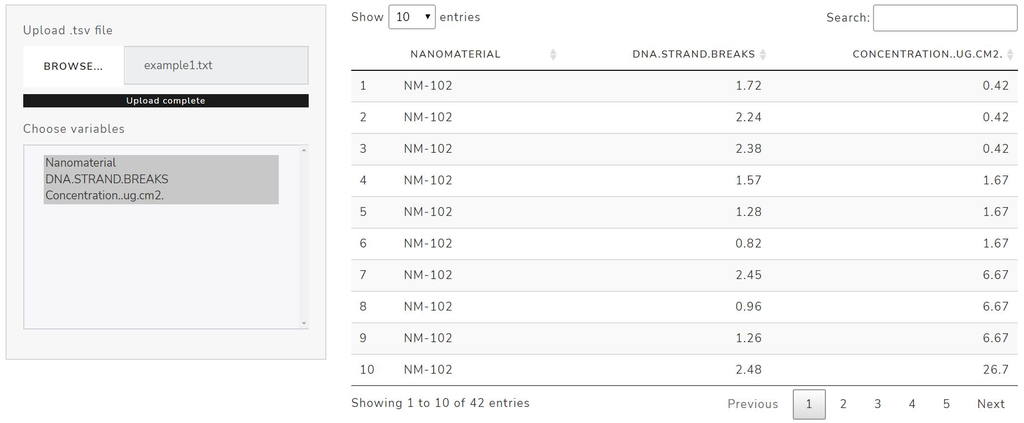

Figure 1: Upload data

To perform the dose-response analysis, the uploaded data should contain variable dose/concentration and response. This data should be a data of one nanomaterial and toxicity endpoint of interest. For the data exploration and preliminary analysis (scatter plot, isotonic plot and trend test), a variable indicating the name of nanomaterial should be available as well (for example, column `NANOMATERIAL` as seen in figure 1. The example 1 dataset presented in figure 1 can be downloaded in menu `DATA EXAMPLES`.

### 2. PLOT AND TREND TEST

In menu `PLOT AND TREND TEST`, we can generate plots of the dose and the response and perform inference to test the trend in the dose-response relationship of nanomaterial toxicity.

To generate the plot or to perform the analysis, the name of the nanomaterial, the response of interest and and the concentration should be selected in the `Choose variable of nanomaterial name`, `Choose variable of response` and `Choose variable of dose` `/concentration` respectively. To generate the scatter plot of the dose and the response, as seen in figure 2, `Scatter plot` should be selected in `The result:`.

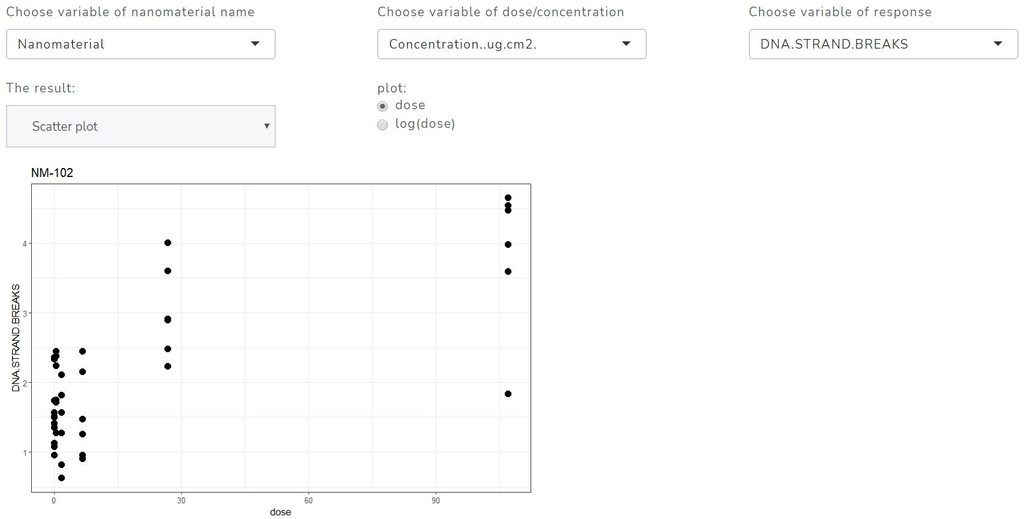

Figure 2: Scatter plot

Figure 3 shows the selections made to generate plot of the dose and the response, with isotonic means. By selecting `Isotonic means plot`, scatter plot with isotonic means will be generated.

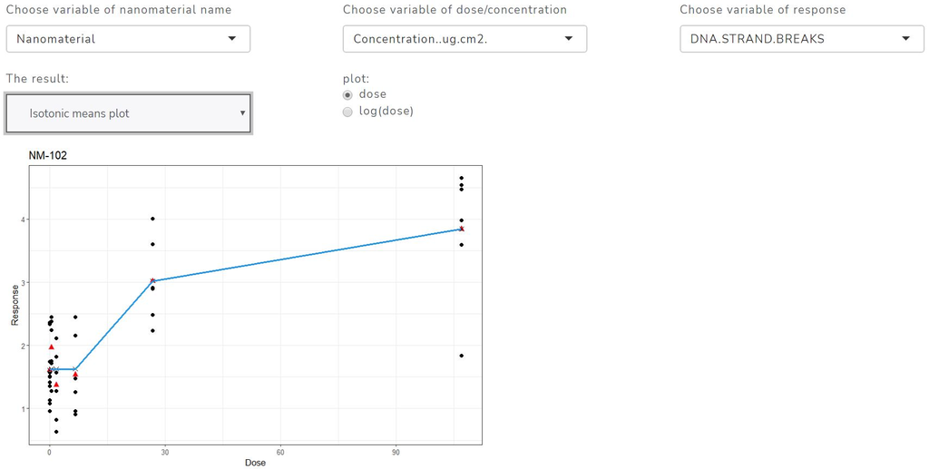

Figure 3: Plot with isotonic means

Figure 4 shows the steps to perform the inference. The method, the seed and the number of permutations can be specified in `Choose the test statistics`, `Specify seed:` and `Number of permutations:`, respectively.

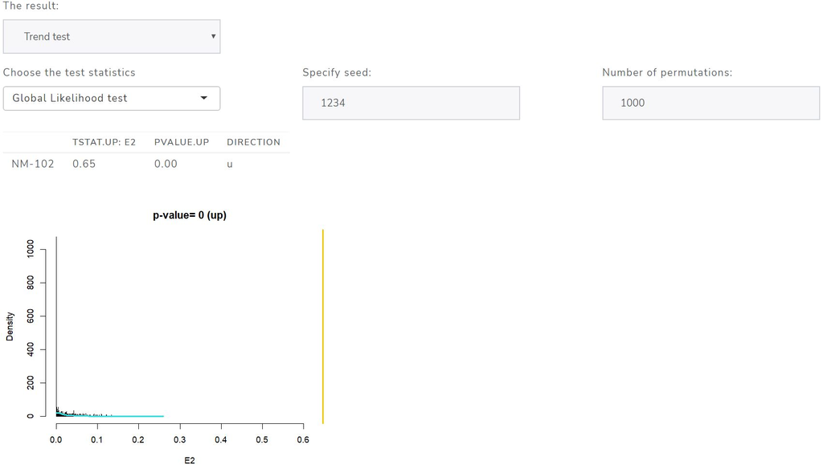

Figure 4: Trend test

### 3. DOSE-RESPONSE MODEL

Menu `DOSE-RESPONSE MODEL` provides option to generate model fitting on the dose-response relationship of nanomaterial toxicity. Several non-linear models are available, such as 3, 4 and 5 parameter log-logistic regression model, Weibull model and Gompertz model. One or more models can be chosen in the option `Select model`. Variable of the dose can be selected in the option `Choose variable of dose/concentration` and variable response can be selected in the `Choose variable of response`. The level of the response (or the ED) can be specified in `Specify ED level`, while the level of the confidence interval can be specified in `The level for the confidence interval`. The approach used to calculate the confidence interval for the estimate of the effective dose by model averaging can be selected in `Calculation of confidence interval.`

As seen in figure 5, ED50 is to be estimated. ED50 estimated here is the dose that is associated with a halfway reduction between the lower and the upper limits of the dose-response curve as doses approach infinity and 0, respectively.

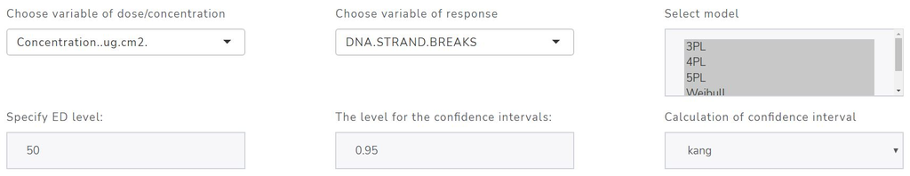

Figure 5: Model fitting

Figure 6 shows the result of the model fitting. It consists of three part: `Result (all models):` containing the fitting result of the all specified models, `Result (inside dose range):` for the result of the model of which its estimate of effective dose lies between the dose range in the data and `Average ED` containing the estimate of the effective dose that is calculated by the model averaging. Only models with effective dose estimates inside dose range (in `Result (inside dose range):`) are considered for the model averaging. The weight for each model is shown in column `weight`.

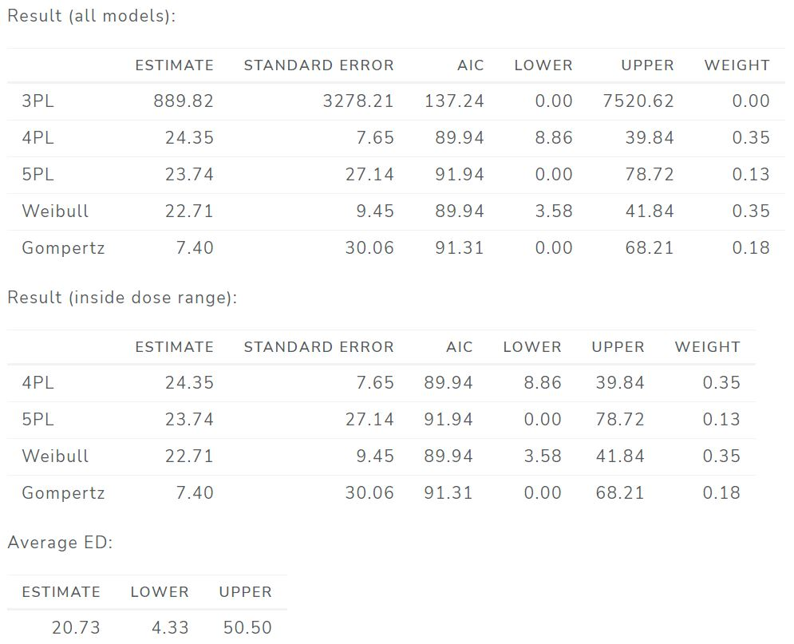

Figure 6: Result of the model fitting

Plot of the dose-response curve will be generated at the same time and is shown under the `Dose-response model plots:`. There are several options to show the plot, `all` to show all specified model fits, `within` to shows the models with estimated effective doses inside the range of the dose, `average & best model` shows the averaged and the best model according to the AIC and each model that is specified can also be plotted individually. In the option `Type of dose`, we can choose to plot the dose in logarithm by selecting `log`. Label of dose (x-axis) and the response (y-axis) can be written in `Type the x-axis label:` and `Type the y-axis label:` respectively.

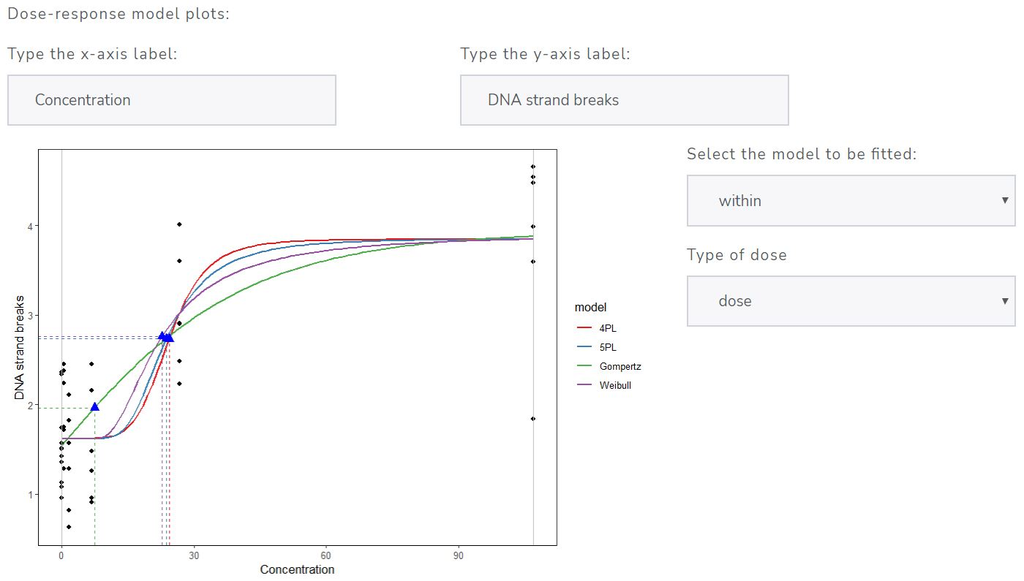

Figure 7: Dose-response model plot

Figure 7 shows the dose-response model plot with the option `within`. The grey vertical lines in the plot indicate the minimum and maxium dose in the dataset. The blue triangles and the black dots represent the ED and the data points, respectively.

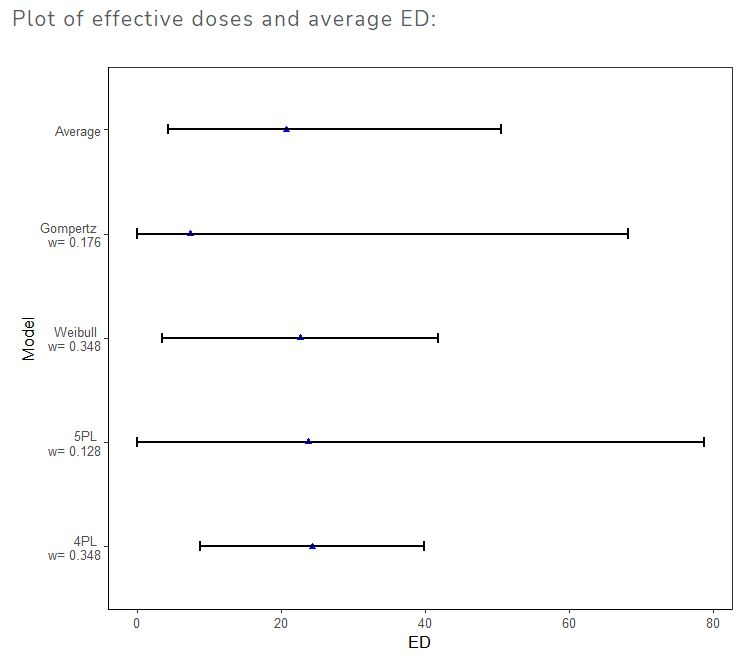

Figure 8: Effective doses plot

### 4. DATA EXAMPLES

Menu `EXAMPLES` stores two examples of dose-response dataset. `Example 1` contains the result of genetic toxicity in vitro studies of NM-102 (Titanium Dioxide, anatase). As seen in figure 9, it consists of variable name of the `NANOMATERIAL` (NM-102), variable `DNA STRAND BREAKS` (the value of the DNA STRAND BREAKS (% DNA in tail)) and variable `CONCENTRATION (UG/CM2)`. Data `Example 1` can be dowloaded through the button `DOWNLOAD EXAMPLE 1`.

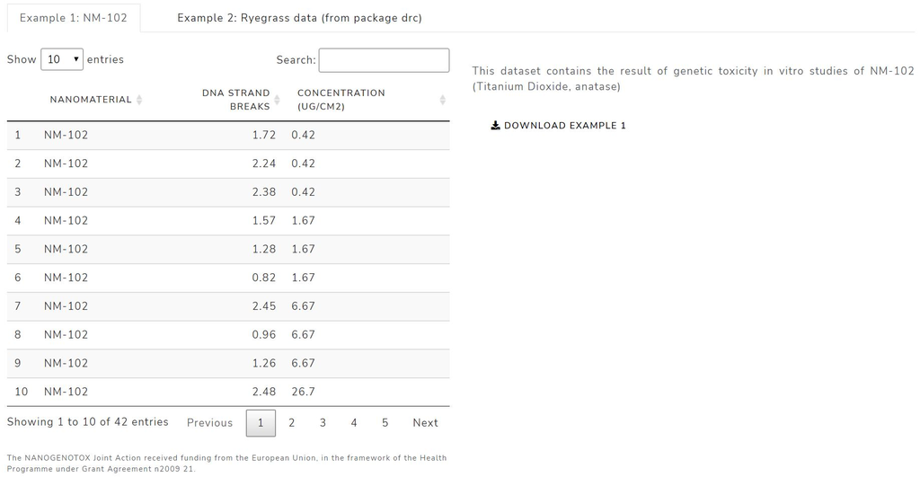

Figure 9: Example 1

Figure 10 shows the second example of a dose-response data. This dataset is ryegrass dataset, which is a part of R package: drc. It comes from part of a study to investigate the joint action of phenolic acids on root growth inhibition of perennial ryegrass *(Lolium perenne L)*. Data `Example 2` can be dowloaded through the button `DOWNLOAD EXAMPLE 2`.

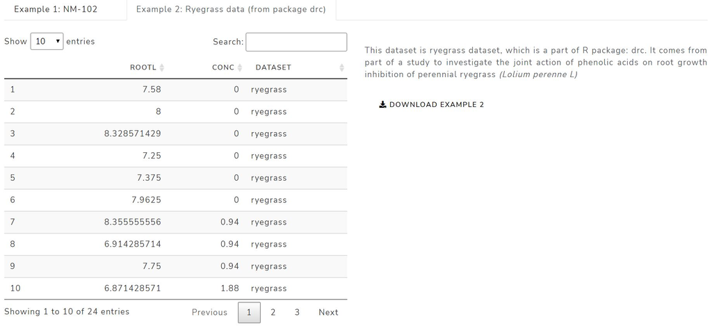

Figure 10: Example 2